# Exploring Job Satisfaction

Kyle Wasserberger

Last Updated: 7/10/2020

# 1 Introduction

The purpose of this assignment was to estimate the relation between satisfaction with pay and morale. Seondary purposes were to elucidate any differences in this relationship dependent on sex and race as well as investigate the moderating effects of percentage of people below the mean morale score within department.

# 2 Data Inport & Cleaning

We start by importing and cleaning the data.

```r
# import
jobsat <- read.table("data/jobsat.txt", header = TRUE)

# change factors to factors
jobsat <- within(jobsat, {
  deptid <- factor(deptid)
  female <- factor(female,labels = c('male','female'))
  white <- factor(white,labels = c('non-white','white'))
})

# view data summary
describe(jobsat, fast = TRUE, check = TRUE) %>%
  round(digits = 2) %>%
  kable() %>%
  kable_styling()
```

|  | vars | n | mean | sd | min | max | range | se |
| --- | --- | --- | --- | --- | --- | --- | --- | --- |
| deptid | 1 | 13189 | NaN | NA | Inf | -Inf | -Inf | NA |
| morale | 2 | 13189 | 26.36 | 6.18 | 11.0 | 40.00 | 29.00 | 0.05 |
| satpay | 3 | 13189 | 8.88 | 3.41 | 0.0 | 16.00 | 16.00 | 0.03 |
| female | 4 | 13189 | NaN | NA | Inf | -Inf | -Inf | NA |
| white | 5 | 13189 | NaN | NA | Inf | -Inf | -Inf | NA |
| pctbelow | 6 | 13189 | 30.55 | 17.15 | 2.4 | 82.90 | 80.50 | 0.15 |
| lev1wt | 7 | 13189 | 1.24 | 0.31 | 1.0 | 3.84 | 2.84 | 0.00 |
| lev2wt | 8 | 13189 | 1.18 | 0.16 | 1.1 | 1.70 | 0.60 | 0.00 |

Basic statistics for relevant variables can be found in the above table. We will ignore *lev1wt* and *lev2wt* for this assignment.

# 3 Data Analysis

## 3.1 Bivariate Scatter Plot and Simple Regression

We can start with some basic scatter plots. First, we can plot the bivariate relationship between *pay satisfaction* andd *morale* for our entire sample.

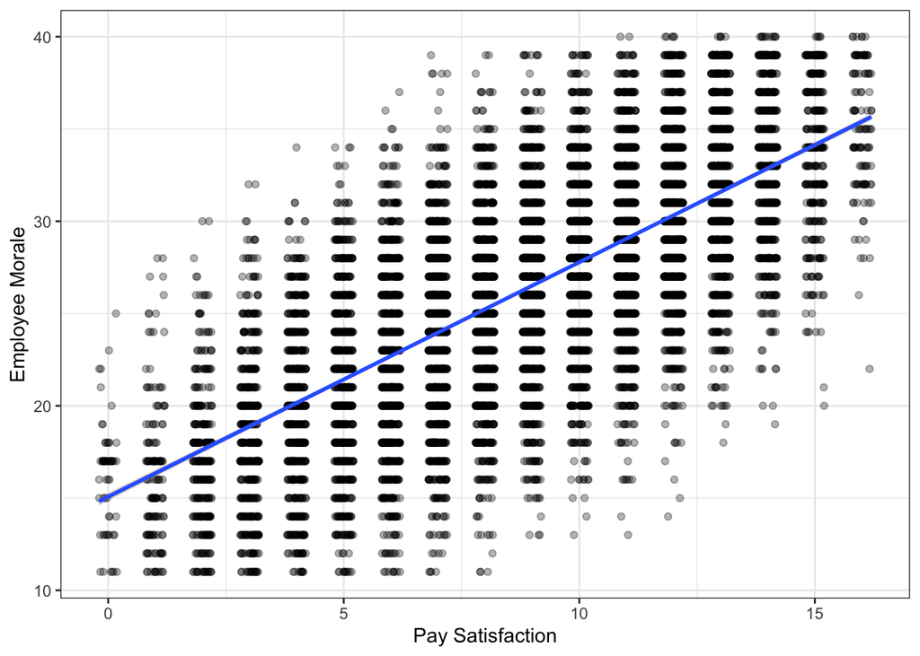

```r
ggplot(jobsat, aes(x = jitter(satpay), y = morale)) +
  geom_point(alpha = .3) +
  theme_bw() +
  geom_smooth(method = 'lm') +
  xlab('Pay Satisfaction') +
  ylab('Employee Morale')
```

We can see a general increase in *morale* as *pay satisfaction* goes up. On average, we would estamate a 1.22 unit increase in *morale* for every 1 unit increase in *pay satisfaction*.

```r
# base model
mod0 <- lmer(morale ~ satpay + (1 | deptid), data = jobsat, REML = FALSE)

# display model
htmlreg(mod0,
        single.row = TRUE,
        caption = 'base model')
```

base model

|  | Model 1 |
| --- | --- |
| (Intercept) | 15.60 (0.15)*** |
| satpay | 1.22 (0.01)*** |
| AIC | 75713.30 |
| BIC | 75743.25 |
| Log Likelihood | -37852.65 |
| Num. obs. | 13189 |
| Num. groups: deptid | 165 |
| Var: deptid (Intercept) | 1.83 |
| Var: Residual | 17.73 |

p < 0.001; p < 0.01; p < 0.05

## 3.2 Race and Sex Dependent Differences

To investigate if the basic relationship between *morale* and *pay satisfaction* changes depending on race or sex we can include each predictor in our linear model.

```r
# race model
mod.r <- lmer(morale ~ satpay + white + (1 | deptid), data = jobsat, REML = FALSE)

# gender model
mod.s <- lmer(morale ~ satpay + female + (1 | deptid), data = jobsat, REML = FALSE)

# display models
htmlreg(list(mod.r,mod.s),
        single.row = TRUE,
        caption = 'Race & Sex Models',
        custom.model.names = c('Race Model','Sex Model'),
        custom.coef.names = c('Intercept','Pay Satisfaction','Race','Sex'))
```

Race & Sex Models

|  | Race Model | Sex Model |
| --- | --- | --- |
| Intercept | 15.35 (0.15)*** | 15.60 (0.15)*** |
| Pay Satisfaction | 1.20 (0.01)*** | 1.22 (0.01)*** |
| Race | 0.92 (0.08)*** |  |
| Sex |  | -0.02 (0.07) |
| AIC | 75576.99 | 75715.25 |
| BIC | 75614.43 | 75752.69 |
| Log Likelihood | -37783.50 | -37852.63 |
| Num. obs. | 13189 | 13189 |
| Num. groups: deptid | 165 | 165 |
| Var: deptid (Intercept) | 1.85 | 1.83 |
| Var: Residual | 17.54 | 17.73 |

p < 0.001; p < 0.01; p < 0.05

We can see that race has a significant effect on morale in our sample while gender does not. We would expect white employees to have a .92 unit higher morale than a non-white employee given the same pay satisfaction score. This is also shown by plotting the data

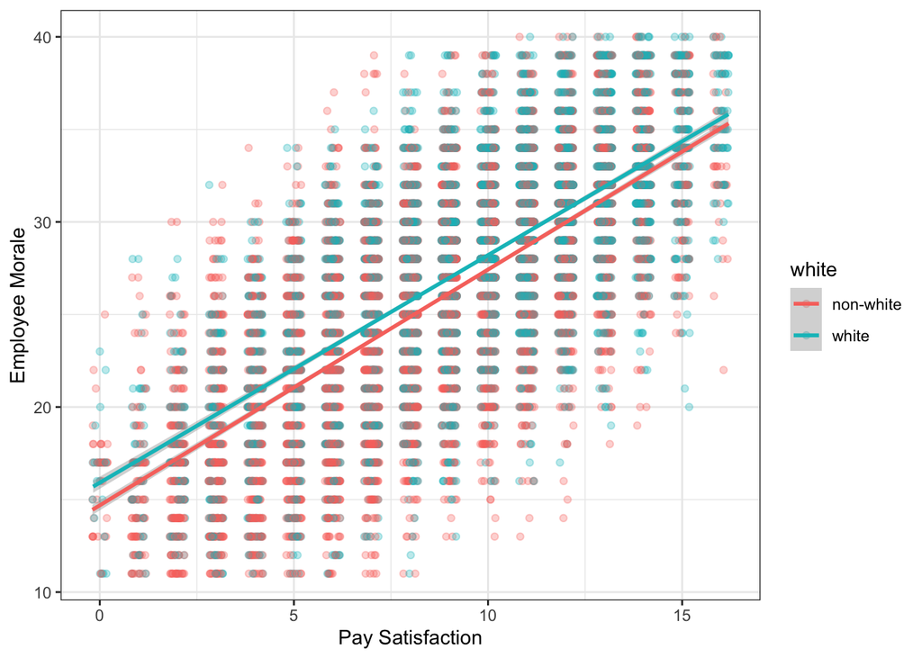

```r
# Plot differences in satpay vs. morale by race
ggplot(jobsat, aes(x = jitter(satpay), y = morale, color = white)) +
  geom_point(alpha = .3) +
  theme_bw() +
  #facet_wrap(~ white) +
  geom_smooth(method = 'lm') +
  xlab('Pay Satisfaction') +
  ylab('Employee Morale')
```

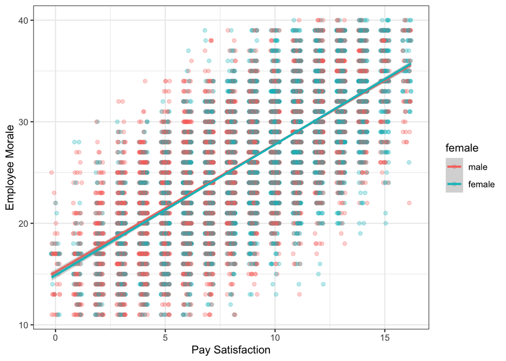

```r
# plot differences in satpay vs. morale by sex
ggplot(jobsat, aes(x = jitter(satpay), y = morale, color = female)) +
  geom_point(alpha = .3) +
  theme_bw() +
  #facet_wrap(~ female) +
  geom_smooth(method = 'lm') +
  xlab('Pay Satisfaction') +
  ylab('Employee Morale')
```

Now lets center some variables for our model building. Once we have our centered variables, we will be able to interpret out models more easily.

```r
# centering function
ctr <- function(x) {x - mean(x)}

# centered variables
c.satpay <- ctr(jobsat$satpay)
c.morale <- ctr(jobsat$morale)
c.pctbelow <- ctr(jobsat$pctbelow)
```

```r
# centered race model
mod.rc <- lmer(morale ~ c.satpay + white + (1 | deptid), data = jobsat, REML = FALSE)

# display models
htmlreg(list(mod.r,mod.rc),
        single.row = TRUE,
        caption = 'Race Models',
        custom.model.names = c('Raw Model','Centered Model'),
        custom.coef.names = c('Intercept','Pay Satisfaction','Race','Pay Satisfaction (centered)'))
```

Race Models

|  | Raw Model | Centered Model |
| --- | --- | --- |
| Intercept | 15.35 (0.15)*** | 26.02 (0.12)*** |
| Pay Satisfaction | 1.20 (0.01)*** |  |
| Race | 0.92 (0.08)*** | 0.92 (0.08)*** |
| Pay Satisfaction (centered) |  | 1.20 (0.01)*** |
| AIC | 75576.99 | 75576.99 |
| BIC | 75614.43 | 75614.43 |
| Log Likelihood | -37783.50 | -37783.50 |
| Num. obs. | 13189 | 13189 |
| Num. groups: deptid | 165 | 165 |
| Var: deptid (Intercept) | 1.85 | 1.85 |
| Var: Residual | 17.54 | 17.54 |

p < 0.001; p < 0.01; p < 0.05

Grand mean centering does not change the predictor coefficients or our model fit statistics. However, it does make our intercept more interpretable. Our centered model intercept represents the predicted morale score for non-white employees with average pay satisfaction. The 0.92 coefficient for *Race* again indicates that the predicted morale for white employees with average pay satisfaction will equal 26.02 + 0.92; or 26.94.

## 3.3 *%below* Mediation

To investigate whether the percentage of employees below the sample mean morale score mediates the relationship between *pay satisfaction* and *morale*, we can use a mediation framework (outlined below).

```r
# step one: test simple regression of pay satisfaction on morale
mod.1 <- lmer(morale ~ c.satpay + (1 | deptid), data = jobsat, REML = FALSE)

# step two: test simple regression of pay satisfaction on %below
mod.2 <- lmer(c.pctbelow ~ c.satpay + (1 | deptid), data = jobsat, REML = FALSE)

# step three: test simple regression of %below on morale
mod.3 <- lmer(morale ~ c.pctbelow + (1 | deptid), data = jobsat, REML = FALSE)

# step four: test multiple regression with pay satisfaction and %below on morale
mod.4 <- lmer(morale ~ c.satpay + c.pctbelow + (1 | deptid), data = jobsat, REML = FALSE)

# need to figure out how to right-justify coefficient cells...
htmlreg(list(mod.1,mod.2,mod.3,mod.4),
        caption = 'Mediation',
        custom.coef.names = c('Intercept','Pay Sat','%below'),
        custom.model.names = c('X on Y','X on M','M on Y','X + M on Y'))
```

Mediation

|  | X on Y | X on M | M on Y | X + M on Y |
| --- | --- | --- | --- | --- |
| Intercept | 26.41*** | -4.78*** | 26.22*** | 26.33*** |
|  | (0.11) | (0.12) | (0.17) | (0.11) |
| Pay Sat | 1.22*** | -0.00 |  | 1.22*** |
|  | (0.01) | (0.00) |  | (0.01) |
| %below |  |  | -0.07*** | -0.03*** |
|  |  |  | (0.01) | (0.01) |
| AIC | 75713.30 | -304681.81 | 84053.45 | 75699.41 |
| BIC | 75743.25 | -304651.86 | 84083.40 | 75736.85 |
| Log Likelihood | -37852.65 | 152344.90 | -42022.73 | -37844.70 |
| Num. obs. | 13189 | 13189 | 13189 | 13189 |
| Num. groups: deptid | 165 | 165 | 165 | 165 |
| Var: deptid (Intercept) | 1.83 | 3.05 | 4.16 | 1.64 |
| Var: Residual | 17.73 | 0.00 | 33.30 | 17.73 |

p < 0.001; p < 0.01; p < 0.05

We can see that both our predictor of interest (*pay satisfaction*) and our mediator of interest (*%below*) are related to morale. However, there is no evidence of a relationship between *pay satisfaction* and *%below*. Furthermore, the direct effect of *pay satisfaction* does not change when introducing the *%below* to the model. This indicates a lack of mediation effect for *%below*.

## 3.4 *%below* Moderation (what the assignment actually asked for)

To investigate whether the percentage of employees below the sample mean morale score moderates the relationship between *pay satisfaction* and *morale*, we can add *pctbelow* and an interaction term between *pay satisfaction* and *pctbelow*.

```r
# main effect model
mod.pct <- lmer(morale ~ c.satpay + c.pctbelow + white + (1 | deptid), data = jobsat, REML = FALSE)

# interaction model
mod.int <- lmer(morale ~ c.satpay*c.pctbelow + white + (1 | deptid), data = jobsat, REML = FALSE)

htmlreg(list(mod.rc, mod.pct, mod.int),
        single.row = TRUE,
        caption = 'Moderation',
        custom.model.names = c('Race Model','%below Main Effect','Moderation Model'),
        custom.coef.names = c('Intercept','Pay Sat','Race','%below','Pay Sat*%below'))
```

Moderation

|  | Race Model | %below Main Effect | Moderation Model |
| --- | --- | --- | --- |
| Intercept | 26.02 (0.12)*** | 25.94 (0.12)*** | 25.96 (0.12)*** |
| Pay Sat | 1.20 (0.01)*** | 1.20 (0.01)*** | 1.20 (0.01)*** |
| Race | 0.92 (0.08)*** | 0.91 (0.08)*** | 0.91 (0.08)*** |
| %below |  | -0.03 (0.01)*** | -0.03 (0.01)*** |
| Pay Sat*%below |  |  | 0.00 (0.00)* |
| AIC | 75576.99 | 75564.79 | 75562.25 |
| BIC | 75614.43 | 75609.71 | 75614.66 |
| Log Likelihood | -37783.50 | -37776.39 | -37774.12 |
| Num. obs. | 13189 | 13189 | 13189 |
| Num. groups: deptid | 165 | 165 | 165 |
| Var: deptid (Intercept) | 1.85 | 1.67 | 1.69 |
| Var: Residual | 17.54 | 17.54 | 17.54 |

p < 0.001; p < 0.01; p < 0.05

From the interaction plot we can see greater moderation effects of *%below* at low levels of pay satisfaction. The effect of *%below* lessens as pay satisfaction increases.

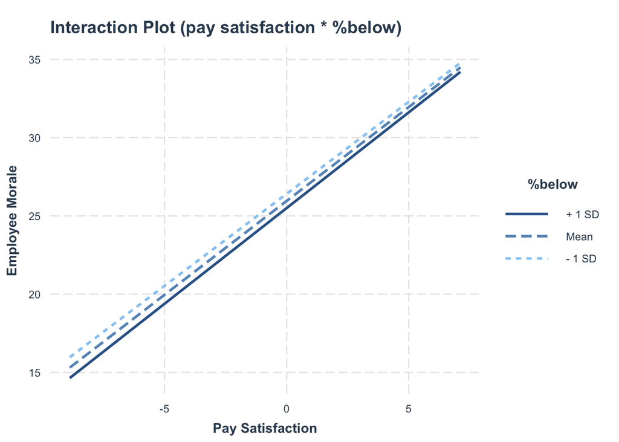

```r
interact_plot(model = mod.int, pred = c.satpay, modx = c.pctbelow,
              legend.main = '%below',
              main.title = 'Interaction Plot (pay satisfaction * %below)',
              x.label = 'Pay Satisfaction',
              y.label = 'Employee Morale')
```

```r
johnson_neyman(model = mod.int, pred = c.satpay, modx = c.pctbelow)
```

JOHNSON-NEYMAN INTERVAL

When c.pctbelow is OUTSIDE the interval [-10790.95, -454.19], the slope of c.satpay is p < .05.

Note: The range of observed values of c.pctbelow is [-28.15, 52.35]

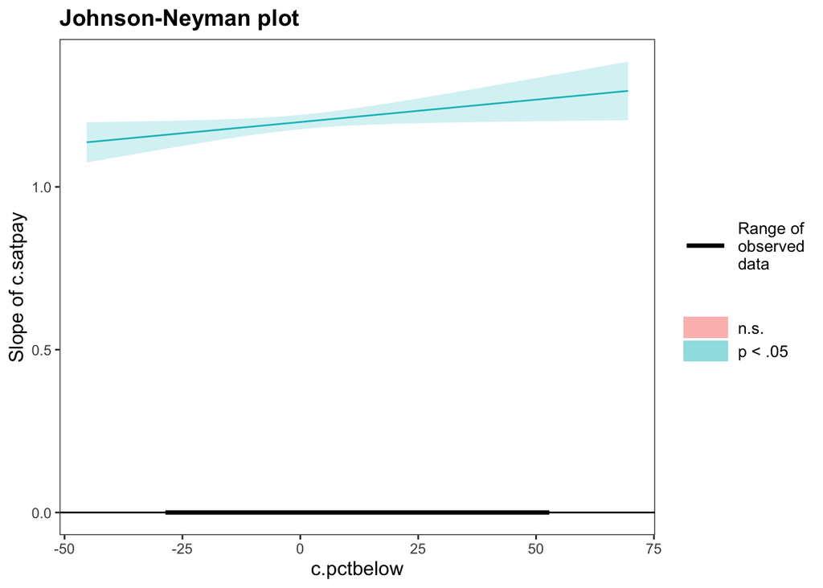